# Structural Equation Models 2019

## Week 4

### Exercise 4.1

Let us import the data file in R, prepare the data and build the model according to the input file. Then let us draw the graph of the initial, full structural equation model.

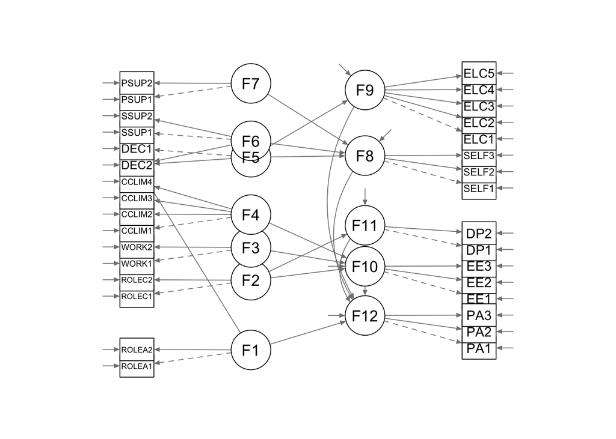

Then let us estimate the initial model using the robust MLM estimator and present a brief summary of the model fit:

```
##         chisq.scaled            df.scaled        pvalue.scaled
##             1541.844              427.000                0.000
## chisq.scaling.factor           cfi.robust           tli.robust
##                1.127                0.945                0.936
##         rmsea.robust
##                0.045
```

In the output Chi square statistic 1541.844 (df = 427, p = 0.000) suggests against a good fit. However the fit indices robust CFI (0.945), robust TLI (0.936) and robust RMSEA (0.045) indicate good fit.

### Exercise 4.2

Then let us print the modification indices (MI) for the model:

```
##      lhs op rhs      mi    epc sepc.lv sepc.all sepc.nox
## 1038 F11  ~  F4 112.597 -0.974  -0.339   -0.339   -0.339
## 1104  F4  ~ F11  90.818 -0.141  -0.404   -0.404   -0.404
## 1037 F11  ~  F3  85.322 -4.799  -4.467   -4.467   -4.467
```

#### Model 2

F11 ~ F4 has the highest MI value. Following the lecture material we specify another model by adding F11 ~ F4:

```
##         chisq.scaled            df.scaled        pvalue.scaled
##             1440.864              426.000                0.000
## chisq.scaling.factor           cfi.robust           tli.robust
##                1.125                0.950                0.942
##         rmsea.robust
##                0.043
```

Let us list the indices from two first models so they can be compared:

```
##    ChiSquare  DF p ChiSq.sc.factor   CFI   TLI RMSEA
## M1  1541.844 427 0           1.127 0.945 0.936 0.045
## M2  1440.864 426 0           1.125 0.950 0.942 0.043
```

The model 2 seems to have better fit than the original model: Chi square statistic is still significant 1440.864 (df = 426, p = 0.000) and suggests against a good fit. However the fit indices robust CFI (0.95), robust TLI (0.942) and robust RMSEA (0.043) all indicate slightly better fit than original model.

Then let us calculate the Chi-Square Difference Test:

```
## [1] 58.9622
```

```
## Scaled Chi Square Difference Test (method = "satorra.bentler.2001")
##
##       Df   AIC   BIC  Chisq Chisq diff Df diff Pr(>Chisq)
## fit2 426 94568 95105 1620.4
## fit  427 94682 95214 1737.1      58.82       1  1.728e-14 ***
## ---
## Signif. codes:  0 '***' 0.001 '**' 0.01 '*' 0.05 '.' 0.1 ' ' 1
```

Both tests show almost exactly the same results and indicate significant difference between models.

#### Model 3

Next, we specify a third model by adding F12 ~ F5:

```
##         chisq.scaled            df.scaled        pvalue.scaled
##             1396.527              425.000                0.000
## chisq.scaling.factor           cfi.robust           tli.robust
##                1.125                0.952                0.944
##         rmsea.robust
##                0.042
```

```
##    ChiSquare  DF p ChiSq.sc.factor   CFI   TLI RMSEA
## M1  1541.844 427 0           1.127 0.945 0.936 0.045
## M2  1440.864 426 0           1.125 0.950 0.942 0.043
## M3  1396.527 425 0           1.125 0.952 0.944 0.042
```

The third model seems to improve the fit from the 2nd model slightly in the same manner as the second model improved the original model.

```
## [1] 44.337
```

The Chi-Square Difference Test indicates that the difference between models is significant.

#### Model 4

Next, we specify a fourth model by adding F9 ~ F2:

```
##         chisq.scaled            df.scaled        pvalue.scaled
##             1356.810              424.000                0.000
## chisq.scaling.factor           cfi.robust           tli.robust
##                1.125                0.954                0.946
##         rmsea.robust
##                0.042
```

```
##    ChiSquare  DF p ChiSq.sc.factor   CFI   TLI RMSEA
## M1  1541.844 427 0           1.127 0.945 0.936 0.045
## M2  1440.864 426 0           1.125 0.950 0.942 0.043
## M3  1396.527 425 0           1.125 0.952 0.944 0.042
## M4  1356.810 424 0           1.125 0.954 0.946 0.042
```

The fourth model seems to improve the fit from the third model slightly in the same manner as the third model improved the second model.

#### Model 5

Next, we specify a fifth model by adding F9 ~ F8:

```
##    ChiSquare  DF p ChiSq.sc.factor   CFI   TLI RMSEA
## M1  1541.844 427 0           1.127 0.945 0.936 0.045
## M2  1440.864 426 0           1.125 0.950 0.942 0.043
## M3  1396.527 425 0           1.125 0.952 0.944 0.042
## M4  1356.810 424 0           1.125 0.954 0.946 0.042
## M5  1323.061 423 0           1.124 0.956 0.948 0.041
```

The fifth model seems to improve the fit from the fourth model slightly in the same manner as the fourth model improved the third model.

#### Model 6

Next, we specify a sixth model by adding F10 ~ F8:

```
##    ChiSquare  DF p ChiSq.sc.factor   CFI   TLI RMSEA
## M1  1541.844 427 0           1.127 0.945 0.936 0.045
## M2  1440.864 426 0           1.125 0.950 0.942 0.043
## M3  1396.527 425 0           1.125 0.952 0.944 0.042
## M4  1356.810 424 0           1.125 0.954 0.946 0.042
## M5  1323.061 423 0           1.124 0.956 0.948 0.041
## M6  1288.246 422 0           1.124 0.958 0.950 0.040
```

The sixth model seems to improve the fit from the fifth model slightly in the same manner as the fifth model improved the fourth model.

#### Model 7

Next, we specify a seventh model by adding F12 ~ F2:

```
##    ChiSquare  DF p ChiSq.sc.factor   CFI   TLI RMSEA
## M1  1541.844 427 0           1.127 0.945 0.936 0.045
## M2  1440.864 426 0           1.125 0.950 0.942 0.043
## M3  1396.527 425 0           1.125 0.952 0.944 0.042
## M4  1356.810 424 0           1.125 0.954 0.946 0.042
## M5  1323.061 423 0           1.124 0.956 0.948 0.041
## M6  1288.246 422 0           1.124 0.958 0.950 0.040
## M7  1267.581 421 0           1.124 0.958 0.951 0.040
```

The seventh model seems to improve the fit from the sixth model slightly in the same manner as the sixth model improved the fifth model.

#### Model 8

The final model 8 is specified by removing F8 ~ F7 and F12 ~ F1:

```
##    ChiSquare  DF p ChiSq.sc.factor   CFI   TLI RMSEA
## M1  1541.844 427 0           1.127 0.945 0.936 0.045
## M2  1440.864 426 0           1.125 0.950 0.942 0.043
## M3  1396.527 425 0           1.125 0.952 0.944 0.042
## M4  1356.810 424 0           1.125 0.954 0.946 0.042
## M5  1323.061 423 0           1.124 0.956 0.948 0.041
## M6  1288.246 422 0           1.124 0.958 0.950 0.040
## M7  1267.581 421 0           1.124 0.958 0.951 0.040
## M8  1275.427 423 0           1.123 0.958 0.951 0.040
```

The final model seems to not improve the fit from the seventh model. All in all all the steps have improved the fit nicely: the Chi Square statistic decreased from 1541.844 to 1275.427, CFI increased from 0.945 to 0.958, TLI increased from 0.936 to 0.951 and RMSEA decreased from 0.045 to 0.040.

### Exercise 4.3

Let us draw the graphs of the original and the final models:

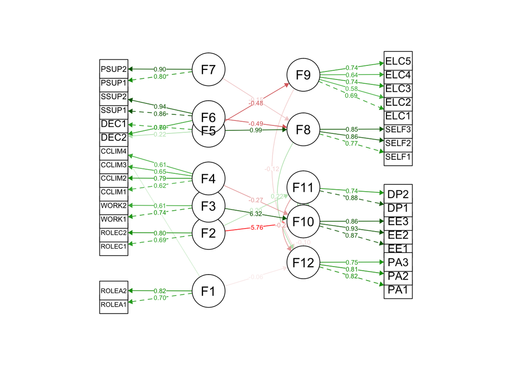

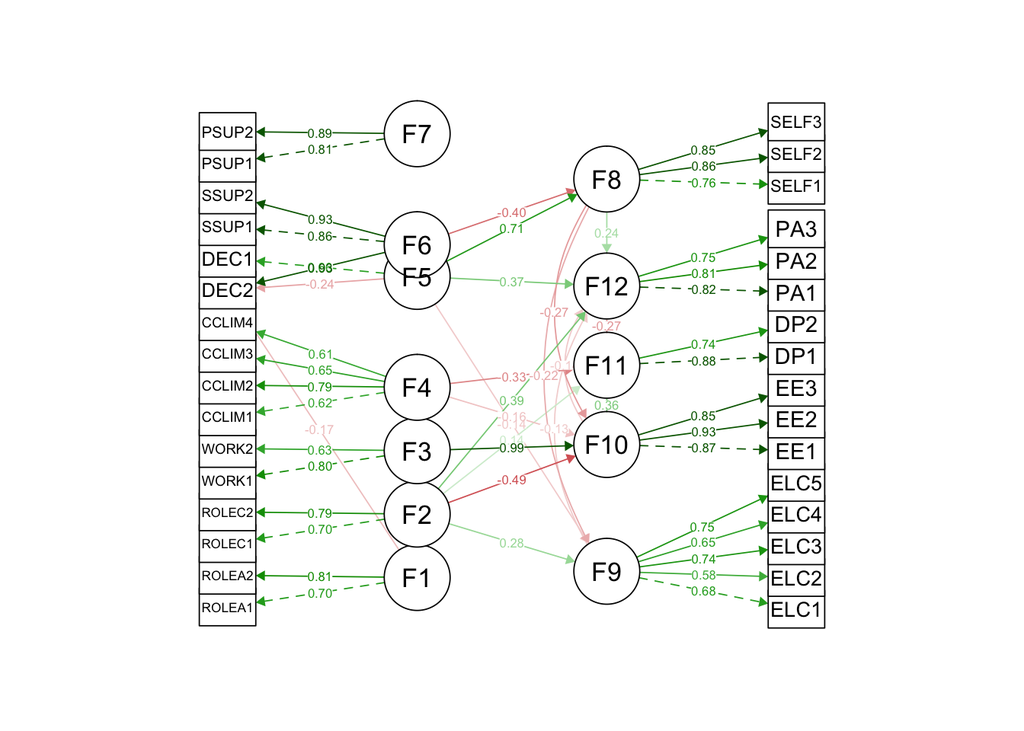